# Risk Factor Analysis

## Outcome Variable

**Outcome Variable:** stunted

## Predictor Variables

**Intervention Variable:** perdiar6

**Adjustment Set:**

- arm
- sex
- W_mage
- meducyrs
- feducyrs
- hhwealth_quart
- hfoodsec
- W_mhtcm
- W_mwtkg
- W_mbmi
- W_birthwt
- W_birthlen
- W_nrooms
- month
- brthmon
- impfloor
- impsan
- safeh20
- delta_W_mage
- delta_meducyrs
- delta_feducyrs
- delta_hhwealth_quart
- delta_hfoodsec
- delta_W_mhtcm
- delta_W_mwtkg
- delta_W_mbmi
- delta_W_birthwt
- delta_W_birthlen
- delta_W_nrooms
- delta_month
- delta_brthmon
- delta_impfloor
- delta_impsan
- delta_safeh20

## Stratifying Variables

The analysis was stratified on these variable(s):

- agecat
- studyid
- country

## Data Summary

| agecat | studyid | country | perdiar6 | stunted | n_cell | n |
| --- | --- | --- | --- | --- | --- | --- |
| Birth | CMIN | BANGLADESH | 0% | 0 | 10 | 26 |
| Birth | CMIN | BANGLADESH | 0% | 1 | 6 | 26 |
| Birth | CMIN | BANGLADESH | (0%, 5%] | 0 | 2 | 26 |
| Birth | CMIN | BANGLADESH | (0%, 5%] | 1 | 2 | 26 |
| Birth | CMIN | BANGLADESH | >5% | 0 | 5 | 26 |
| Birth | CMIN | BANGLADESH | >5% | 1 | 1 | 26 |
| Birth | CONTENT | PERU | 0% | 0 | 0 | 2 |
| Birth | CONTENT | PERU | 0% | 1 | 0 | 2 |
| Birth | CONTENT | PERU | (0%, 5%] | 0 | 1 | 2 |
| Birth | CONTENT | PERU | (0%, 5%] | 1 | 0 | 2 |
| Birth | CONTENT | PERU | >5% | 0 | 1 | 2 |
| Birth | CONTENT | PERU | >5% | 1 | 0 | 2 |
| Birth | EE | PAKISTAN | 0% | 0 | 132 | 240 |
| Birth | EE | PAKISTAN | 0% | 1 | 91 | 240 |
| Birth | EE | PAKISTAN | (0%, 5%] | 0 | 7 | 240 |
| Birth | EE | PAKISTAN | (0%, 5%] | 1 | 8 | 240 |
| Birth | EE | PAKISTAN | >5% | 0 | 1 | 240 |
| Birth | EE | PAKISTAN | >5% | 1 | 1 | 240 |
| Birth | MAL-ED | BANGLADESH | 0% | 0 | 58 | 231 |
| Birth | MAL-ED | BANGLADESH | 0% | 1 | 14 | 231 |
| Birth | MAL-ED | BANGLADESH | (0%, 5%] | 0 | 78 | 231 |
| Birth | MAL-ED | BANGLADESH | (0%, 5%] | 1 | 12 | 231 |
| Birth | MAL-ED | BANGLADESH | >5% | 0 | 51 | 231 |
| Birth | MAL-ED | BANGLADESH | >5% | 1 | 18 | 231 |
| Birth | MAL-ED | BRAZIL | 0% | 0 | 48 | 65 |
| Birth | MAL-ED | BRAZIL | 0% | 1 | 9 | 65 |
| Birth | MAL-ED | BRAZIL | (0%, 5%] | 0 | 6 | 65 |
| Birth | MAL-ED | BRAZIL | (0%, 5%] | 1 | 0 | 65 |
| Birth | MAL-ED | BRAZIL | >5% | 0 | 2 | 65 |
| Birth | MAL-ED | BRAZIL | >5% | 1 | 0 | 65 |

[output cut: 204 more lines]

The following strata were considered:

- agecat: 24 months, studyid: CMIN, country: BANGLADESH
- agecat: 24 months, studyid: CONTENT, country: PERU
- agecat: 24 months, studyid: EE, country: PAKISTAN
- agecat: 24 months, studyid: MAL-ED, country: BANGLADESH
- agecat: 24 months, studyid: MAL-ED, country: BRAZIL
- agecat: 24 months, studyid: MAL-ED, country: INDIA
- agecat: 24 months, studyid: MAL-ED, country: NEPAL
- agecat: 24 months, studyid: MAL-ED, country: PERU
- agecat: 24 months, studyid: MAL-ED, country: SOUTH AFRICA
- agecat: 24 months, studyid: MAL-ED, country: TANZANIA, UNITED REPUBLIC OF
- agecat: 24 months, studyid: NIH-Birth, country: BANGLADESH
- agecat: 24 months, studyid: NIH-Crypto, country: BANGLADESH
- agecat: 24 months, studyid: PROVIDE, country: BANGLADESH
- agecat: 6 months, studyid: CMIN, country: BANGLADESH
- agecat: 6 months, studyid: CONTENT, country: PERU
- agecat: 6 months, studyid: EE, country: PAKISTAN
- agecat: 6 months, studyid: MAL-ED, country: BANGLADESH
- agecat: 6 months, studyid: MAL-ED, country: BRAZIL
- agecat: 6 months, studyid: MAL-ED, country: INDIA
- agecat: 6 months, studyid: MAL-ED, country: NEPAL
- agecat: 6 months, studyid: MAL-ED, country: PERU
- agecat: 6 months, studyid: MAL-ED, country: SOUTH AFRICA
- agecat: 6 months, studyid: MAL-ED, country: TANZANIA, UNITED REPUBLIC OF
- agecat: 6 months, studyid: NIH-Birth, country: BANGLADESH
- agecat: 6 months, studyid: NIH-Crypto, country: BANGLADESH
- agecat: 6 months, studyid: PROVIDE, country: BANGLADESH
- agecat: Birth, studyid: CMIN, country: BANGLADESH
- agecat: Birth, studyid: CONTENT, country: PERU
- agecat: Birth, studyid: EE, country: PAKISTAN
- agecat: Birth, studyid: MAL-ED, country: BANGLADESH
- agecat: Birth, studyid: MAL-ED, country: BRAZIL
- agecat: Birth, studyid: MAL-ED, country: INDIA
- agecat: Birth, studyid: MAL-ED, country: NEPAL
- agecat: Birth, studyid: MAL-ED, country: PERU
- agecat: Birth, studyid: MAL-ED, country: SOUTH AFRICA
- agecat: Birth, studyid: MAL-ED, country: TANZANIA, UNITED REPUBLIC OF
- agecat: Birth, studyid: NIH-Birth, country: BANGLADESH
- agecat: Birth, studyid: NIH-Crypto, country: BANGLADESH
- agecat: Birth, studyid: PROVIDE, country: BANGLADESH

### Dropped Strata

Some strata were dropped due to rare outcomes:

- agecat: Birth, studyid: CMIN, country: BANGLADESH
- agecat: Birth, studyid: CONTENT, country: PERU
- agecat: Birth, studyid: EE, country: PAKISTAN
- agecat: Birth, studyid: MAL-ED, country: BRAZIL
- agecat: Birth, studyid: MAL-ED, country: INDIA
- agecat: Birth, studyid: MAL-ED, country: NEPAL
- agecat: Birth, studyid: MAL-ED, country: SOUTH AFRICA
- agecat: Birth, studyid: MAL-ED, country: TANZANIA, UNITED REPUBLIC OF
- agecat: 6 months, studyid: CONTENT, country: PERU
- agecat: 6 months, studyid: EE, country: PAKISTAN
- agecat: 6 months, studyid: MAL-ED, country: BRAZIL
- agecat: 6 months, studyid: MAL-ED, country: NEPAL
- agecat: 6 months, studyid: MAL-ED, country: SOUTH AFRICA
- agecat: 24 months, studyid: CONTENT, country: PERU
- agecat: 24 months, studyid: EE, country: PAKISTAN
- agecat: 24 months, studyid: MAL-ED, country: BRAZIL
- agecat: 24 months, studyid: MAL-ED, country: SOUTH AFRICA

## Methods Detail

We’re interested in the causal parameters $E[Y_a]$ for all values of $a \in \mathcal{A}$. These parameters represent the mean outcome if, possibly contrary to fact, we intervened to set all units to have $A=a$. Under the randomization and positivity assumptions, these are identified by the statistical parameters $\psi_a=E_W[E_{Y|A,W}(Y|A=a,W)]$. In addition, we’re interested in the mean of $Y$, $E[Y]$ under no intervention (the observed mean). We will estimate these parameters by using SuperLearner to fit the relevant likelihood factors – $E_{Y|A,W}(Y|A=a,W)$ and $p(A=a|W)$, and then updating our likelihood fit using a joint TMLE.

For unadjusted analyses ($W=\{\}$), initial likelihoods were estimated using Lrnr_glm to estimate the simple $E(Y|A)$ and Lrnr_mean to estimate $p(A)$. For adjusted analyses, a small library containing Lrnr_glmnet, Lrnr_xgboost, and Lrnr_mean was used.

Having estimated these parameters, we will then use the delta method to estimate relative risks and attributable risks relative to a prespecified baseline level of $A$.

# Results Detail

## Results Plots

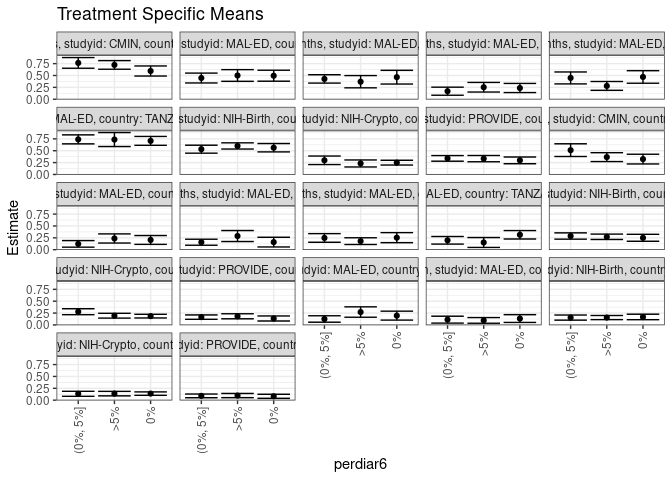

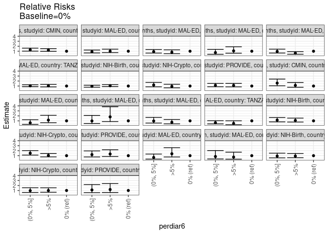

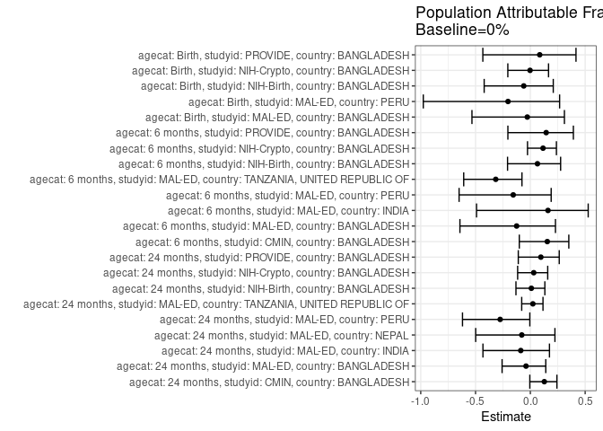

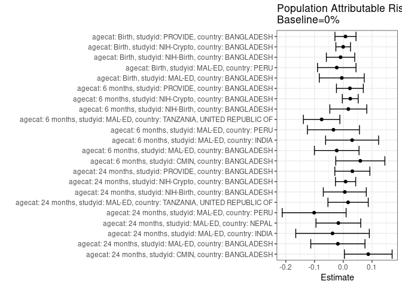

## Results Table

### Parameter: TSM

| agecat | studyid | country | intervention_level | baseline_level | estimate | ci_lower | ci_upper |
| --- | --- | --- | --- | --- | --- | --- | --- |
| Birth | MAL-ED | BANGLADESH | 0% | NA | 0.1957728 | 0.1015849 | 0.2899606 |
| Birth | MAL-ED | BANGLADESH | (0%, 5%] | NA | 0.1255230 | 0.0578257 | 0.1932204 |
| Birth | MAL-ED | BANGLADESH | >5% | NA | 0.2714371 | 0.1620647 | 0.3808095 |
| Birth | MAL-ED | PERU | 0% | NA | 0.1343284 | 0.0524998 | 0.2161570 |
| Birth | MAL-ED | PERU | (0%, 5%] | NA | 0.1111111 | 0.0383636 | 0.1838586 |
| Birth | MAL-ED | PERU | >5% | NA | 0.0957447 | 0.0361344 | 0.1553549 |
| Birth | NIH-Birth | BANGLADESH | 0% | NA | 0.1682449 | 0.1102747 | 0.2262151 |
| Birth | NIH-Birth | BANGLADESH | (0%, 5%] | NA | 0.1548253 | 0.1013280 | 0.2083227 |
| Birth | NIH-Birth | BANGLADESH | >5% | NA | 0.1552092 | 0.1113771 | 0.1990412 |
| Birth | NIH-Crypto | BANGLADESH | 0% | NA | 0.1383488 | 0.1024779 | 0.1742197 |
| Birth | NIH-Crypto | BANGLADESH | (0%, 5%] | NA | 0.1341276 | 0.0818336 | 0.1864216 |
| Birth | NIH-Crypto | BANGLADESH | >5% | NA | 0.1380339 | 0.0907006 | 0.1853672 |
| Birth | PROVIDE | BANGLADESH | 0% | NA | 0.0814528 | 0.0385122 | 0.1243934 |
| Birth | PROVIDE | BANGLADESH | (0%, 5%] | NA | 0.0903715 | 0.0513047 | 0.1294382 |
| Birth | PROVIDE | BANGLADESH | >5% | NA | 0.0970241 | 0.0528282 | 0.1412201 |
| 6 months | CMIN | BANGLADESH | 0% | NA | 0.3235157 | 0.2211970 | 0.4258344 |
| 6 months | CMIN | BANGLADESH | (0%, 5%] | NA | 0.5121312 | 0.3783381 | 0.6459244 |
| 6 months | CMIN | BANGLADESH | >5% | NA | 0.3654963 | 0.2721973 | 0.4587952 |
| 6 months | MAL-ED | BANGLADESH | 0% | NA | 0.2054356 | 0.1123955 | 0.2984757 |
| 6 months | MAL-ED | BANGLADESH | (0%, 5%] | NA | 0.1227359 | 0.0539069 | 0.1915649 |
| 6 months | MAL-ED | BANGLADESH | >5% | NA | 0.2366057 | 0.1405855 | 0.3326260 |
| 6 months | MAL-ED | INDIA | 0% | NA | 0.1600000 | 0.0581679 | 0.2618321 |
| 6 months | MAL-ED | INDIA | (0%, 5%] | NA | 0.1574803 | 0.0939953 | 0.2209654 |
| 6 months | MAL-ED | INDIA | >5% | NA | 0.2881356 | 0.1723269 | 0.4039443 |
| 6 months | MAL-ED | PERU | 0% | NA | 0.2540984 | 0.1483509 | 0.3598459 |
| 6 months | MAL-ED | PERU | (0%, 5%] | NA | 0.2475406 | 0.1566883 | 0.3383930 |
| 6 months | MAL-ED | PERU | >5% | NA | 0.1805164 | 0.1098573 | 0.2511756 |
| 6 months | MAL-ED | TANZANIA, UNITED REPUBLIC OF | 0% | NA | 0.3142857 | 0.2253107 | 0.4032608 |
| 6 months | MAL-ED | TANZANIA, UNITED REPUBLIC OF | (0%, 5%] | NA | 0.1979167 | 0.1180539 | 0.2777794 |
| 6 months | MAL-ED | TANZANIA, UNITED REPUBLIC OF | >5% | NA | 0.1521739 | 0.0481643 | 0.2561836 |
| 6 months | NIH-Birth | BANGLADESH | 0% | NA | 0.2507613 | 0.1775324 | 0.3239903 |
| 6 months | NIH-Birth | BANGLADESH | (0%, 5%] | NA | 0.2882219 | 0.2219761 | 0.3544678 |
| 6 months | NIH-Birth | BANGLADESH | >5% | NA | 0.2720082 | 0.2156857 | 0.3283307 |
| 6 months | NIH-Crypto | BANGLADESH | 0% | NA | 0.1855122 | 0.1467009 | 0.2243235 |
| 6 months | NIH-Crypto | BANGLADESH | (0%, 5%] | NA | 0.2784997 | 0.2156200 | 0.3413794 |
| 6 months | NIH-Crypto | BANGLADESH | >5% | NA | 0.1943707 | 0.1438874 | 0.2448540 |
| 6 months | PROVIDE | BANGLADESH | 0% | NA | 0.1359824 | 0.0830438 | 0.1889210 |
| 6 months | PROVIDE | BANGLADESH | (0%, 5%] | NA | 0.1646946 | 0.1187916 | 0.2105976 |
| 6 months | PROVIDE | BANGLADESH | >5% | NA | 0.1822590 | 0.1291927 | 0.2353254 |
| 24 months | CMIN | BANGLADESH | 0% | NA | 0.5949133 | 0.4890047 | 0.7008218 |
| 24 months | CMIN | BANGLADESH | (0%, 5%] | NA | 0.7651190 | 0.6529539 | 0.8772841 |
| 24 months | CMIN | BANGLADESH | >5% | NA | 0.7229625 | 0.6323308 | 0.8135943 |
| 24 months | MAL-ED | BANGLADESH | 0% | NA | 0.4953091 | 0.3801285 | 0.6104897 |
| 24 months | MAL-ED | BANGLADESH | (0%, 5%] | NA | 0.4470481 | 0.3431836 | 0.5509126 |
| 24 months | MAL-ED | BANGLADESH | >5% | NA | 0.5005485 | 0.3771191 | 0.6239778 |
| 24 months | MAL-ED | INDIA | 0% | NA | 0.4647176 | 0.3205033 | 0.6089319 |
| 24 months | MAL-ED | INDIA | (0%, 5%] | NA | 0.4279680 | 0.3398712 | 0.5160647 |
| 24 months | MAL-ED | INDIA | >5% | NA | 0.3690484 | 0.2399448 | 0.4981520 |
| 24 months | MAL-ED | NEPAL | 0% | NA | 0.2364647 | 0.1401705 | 0.3327590 |
| 24 months | MAL-ED | NEPAL | (0%, 5%] | NA | 0.1694273 | 0.0843571 | 0.2544976 |
| 24 months | MAL-ED | NEPAL | >5% | NA | 0.2528052 | 0.1519857 | 0.3536247 |
| 24 months | MAL-ED | PERU | 0% | NA | 0.4695622 | 0.3375161 | 0.6016084 |
| 24 months | MAL-ED | PERU | (0%, 5%] | NA | 0.4488612 | 0.3231018 | 0.5746205 |
| 24 months | MAL-ED | PERU | >5% | NA | 0.2803459 | 0.1873683 | 0.3733235 |
| 24 months | MAL-ED | TANZANIA, UNITED REPUBLIC OF | 0% | NA | 0.7076023 | 0.6142314 | 0.8009733 |
| 24 months | MAL-ED | TANZANIA, UNITED REPUBLIC OF | (0%, 5%] | NA | 0.7391583 | 0.6444595 | 0.8338571 |
| 24 months | MAL-ED | TANZANIA, UNITED REPUBLIC OF | >5% | NA | 0.7355810 | 0.5881807 | 0.8829812 |
| 24 months | NIH-Birth | BANGLADESH | 0% | NA | 0.5635177 | 0.4753244 | 0.6517110 |
| 24 months | NIH-Birth | BANGLADESH | (0%, 5%] | NA | 0.5325386 | 0.4486963 | 0.6163809 |
| 24 months | NIH-Birth | BANGLADESH | >5% | NA | 0.6010893 | 0.5354174 | 0.6667613 |
| 24 months | NIH-Crypto | BANGLADESH | 0% | NA | 0.2488733 | 0.1984753 | 0.2992713 |
| 24 months | NIH-Crypto | BANGLADESH | (0%, 5%] | NA | 0.2983374 | 0.2086162 | 0.3880587 |
| 24 months | NIH-Crypto | BANGLADESH | >5% | NA | 0.2320195 | 0.1583413 | 0.3056976 |
| 24 months | PROVIDE | BANGLADESH | 0% | NA | 0.2972138 | 0.2263083 | 0.3681193 |
| 24 months | PROVIDE | BANGLADESH | (0%, 5%] | NA | 0.3390156 | 0.2796808 | 0.3983503 |
| 24 months | PROVIDE | BANGLADESH | >5% | NA | 0.3339948 | 0.2680763 | 0.3999133 |

### Parameter: E(Y)

| agecat | studyid | country | intervention_level | baseline_level | estimate | ci_lower | ci_upper |
| --- | --- | --- | --- | --- | --- | --- | --- |
| Birth | MAL-ED | BANGLADESH | NA | NA | 0.1904762 | 0.1397281 | 0.2412242 |
| Birth | MAL-ED | PERU | NA | NA | 0.1115880 | 0.0710726 | 0.1521034 |
| Birth | NIH-Birth | BANGLADESH | NA | NA | 0.1586777 | 0.1295391 | 0.1878163 |
| Birth | NIH-Crypto | BANGLADESH | NA | NA | 0.1379781 | 0.1129774 | 0.1629789 |
| Birth | PROVIDE | BANGLADESH | NA | NA | 0.0890538 | 0.0649864 | 0.1131212 |
| 6 months | CMIN | BANGLADESH | NA | NA | 0.3827160 | 0.3214780 | 0.4439541 |
| 6 months | MAL-ED | BANGLADESH | NA | NA | 0.1825726 | 0.1336978 | 0.2314474 |
| 6 months | MAL-ED | INDIA | NA | NA | 0.1906780 | 0.1404524 | 0.2409036 |
| 6 months | MAL-ED | PERU | NA | NA | 0.2197802 | 0.1705687 | 0.2689917 |
| 6 months | MAL-ED | TANZANIA, UNITED REPUBLIC OF | NA | NA | 0.2388664 | 0.1855834 | 0.2921494 |
| 6 months | NIH-Birth | BANGLADESH | NA | NA | 0.2681564 | 0.2306532 | 0.3056597 |
| 6 months | NIH-Crypto | BANGLADESH | NA | NA | 0.2097902 | 0.1799252 | 0.2396552 |
| 6 months | PROVIDE | BANGLADESH | NA | NA | 0.1589404 | 0.1297581 | 0.1881227 |
| 24 months | CMIN | BANGLADESH | NA | NA | 0.6818182 | 0.6230135 | 0.7406228 |
| 24 months | MAL-ED | BANGLADESH | NA | NA | 0.4764151 | 0.4090254 | 0.5438047 |
| 24 months | MAL-ED | INDIA | NA | NA | 0.4273128 | 0.3628178 | 0.4918077 |
| 24 months | MAL-ED | NEPAL | NA | NA | 0.2192982 | 0.1654718 | 0.2731246 |
| 24 months | MAL-ED | PERU | NA | NA | 0.3681592 | 0.3013164 | 0.4350020 |
| 24 months | MAL-ED | TANZANIA, UNITED REPUBLIC OF | NA | NA | 0.7242991 | 0.6642873 | 0.7843108 |
| 24 months | NIH-Birth | BANGLADESH | NA | NA | 0.5687646 | 0.5218455 | 0.6156837 |
| 24 months | NIH-Crypto | BANGLADESH | NA | NA | 0.2568093 | 0.2190047 | 0.2946140 |
| 24 months | PROVIDE | BANGLADESH | NA | NA | 0.3287197 | 0.2903909 | 0.3670485 |

### Parameter: RR

| agecat | studyid | country | intervention_level | baseline_level | estimate | ci_lower | ci_upper |
| --- | --- | --- | --- | --- | --- | --- | --- |
| Birth | MAL-ED | BANGLADESH | 0% | 0% | 1.0000000 | 1.0000000 | 1.0000000 |
| Birth | MAL-ED | BANGLADESH | (0%, 5%] | 0% | 0.6411669 | 0.3113369 | 1.3204185 |
| Birth | MAL-ED | BANGLADESH | >5% | 0% | 1.3864906 | 0.7402077 | 2.5970497 |
| Birth | MAL-ED | PERU | 0% | 0% | 1.0000000 | 1.0000000 | 1.0000000 |
| Birth | MAL-ED | PERU | (0%, 5%] | 0% | 0.8271605 | 0.3382241 | 2.0229029 |
| Birth | MAL-ED | PERU | >5% | 0% | 0.7127660 | 0.2983038 | 1.7030804 |
| Birth | NIH-Birth | BANGLADESH | 0% | 0% | 1.0000000 | 1.0000000 | 1.0000000 |
| Birth | NIH-Birth | BANGLADESH | (0%, 5%] | 0% | 0.9202380 | 0.5652023 | 1.4982918 |
| Birth | NIH-Birth | BANGLADESH | >5% | 0% | 0.9225193 | 0.5909790 | 1.4400545 |
| Birth | NIH-Crypto | BANGLADESH | 0% | 0% | 1.0000000 | 1.0000000 | 1.0000000 |
| Birth | NIH-Crypto | BANGLADESH | (0%, 5%] | 0% | 0.9694886 | 0.6071954 | 1.5479499 |
| Birth | NIH-Crypto | BANGLADESH | >5% | 0% | 0.9977241 | 0.6489363 | 1.5339771 |
| Birth | PROVIDE | BANGLADESH | 0% | 0% | 1.0000000 | 1.0000000 | 1.0000000 |
| Birth | PROVIDE | BANGLADESH | (0%, 5%] | 0% | 1.1094946 | 0.5613295 | 2.1929692 |
| Birth | PROVIDE | BANGLADESH | >5% | 0% | 1.1911696 | 0.5926249 | 2.3942379 |
| 6 months | CMIN | BANGLADESH | 0% | 0% | 1.0000000 | 1.0000000 | 1.0000000 |
| 6 months | CMIN | BANGLADESH | (0%, 5%] | 0% | 1.5830180 | 1.0494810 | 2.3877954 |
| 6 months | CMIN | BANGLADESH | >5% | 0% | 1.1297636 | 0.7517057 | 1.6979594 |
| 6 months | MAL-ED | BANGLADESH | 0% | 0% | 1.0000000 | 1.0000000 | 1.0000000 |
| 6 months | MAL-ED | BANGLADESH | (0%, 5%] | 0% | 0.5974421 | 0.2907564 | 1.2276153 |
| 6 months | MAL-ED | BANGLADESH | >5% | 0% | 1.1517268 | 0.6276825 | 2.1132893 |
| 6 months | MAL-ED | INDIA | 0% | 0% | 1.0000000 | 1.0000000 | 1.0000000 |
| 6 months | MAL-ED | INDIA | (0%, 5%] | 0% | 0.9842520 | 0.4633583 | 2.0907189 |
| 6 months | MAL-ED | INDIA | >5% | 0% | 1.8008475 | 0.8483352 | 3.8228424 |
| 6 months | MAL-ED | PERU | 0% | 0% | 1.0000000 | 1.0000000 | 1.0000000 |
| 6 months | MAL-ED | PERU | (0%, 5%] | 0% | 0.9741920 | 0.5587539 | 1.6985117 |
| 6 months | MAL-ED | PERU | >5% | 0% | 0.7104193 | 0.4009950 | 1.2586082 |
| 6 months | MAL-ED | TANZANIA, UNITED REPUBLIC OF | 0% | 0% | 1.0000000 | 1.0000000 | 1.0000000 |
| 6 months | MAL-ED | TANZANIA, UNITED REPUBLIC OF | (0%, 5%] | 0% | 0.6297348 | 0.3846662 | 1.0309354 |
| 6 months | MAL-ED | TANZANIA, UNITED REPUBLIC OF | >5% | 0% | 0.4841897 | 0.2310592 | 1.0146303 |
| 6 months | NIH-Birth | BANGLADESH | 0% | 0% | 1.0000000 | 1.0000000 | 1.0000000 |
| 6 months | NIH-Birth | BANGLADESH | (0%, 5%] | 0% | 1.1493875 | 0.7939608 | 1.6639255 |
| 6 months | NIH-Birth | BANGLADESH | >5% | 0% | 1.0847294 | 0.7602393 | 1.5477205 |
| 6 months | NIH-Crypto | BANGLADESH | 0% | 0% | 1.0000000 | 1.0000000 | 1.0000000 |
| 6 months | NIH-Crypto | BANGLADESH | (0%, 5%] | 0% | 1.5012476 | 1.1191967 | 2.0137160 |
| 6 months | NIH-Crypto | BANGLADESH | >5% | 0% | 1.0477517 | 0.7615679 | 1.4414783 |
| 6 months | PROVIDE | BANGLADESH | 0% | 0% | 1.0000000 | 1.0000000 | 1.0000000 |
| 6 months | PROVIDE | BANGLADESH | (0%, 5%] | 0% | 1.2111466 | 0.7505362 | 1.9544374 |
| 6 months | PROVIDE | BANGLADESH | >5% | 0% | 1.3403136 | 0.8246975 | 2.1783024 |
| 24 months | CMIN | BANGLADESH | 0% | 0% | 1.0000000 | 1.0000000 | 1.0000000 |
| 24 months | CMIN | BANGLADESH | (0%, 5%] | 0% | 1.2861018 | 1.0216020 | 1.6190825 |
| 24 months | CMIN | BANGLADESH | >5% | 0% | 1.2152403 | 0.9769963 | 1.5115808 |
| 24 months | MAL-ED | BANGLADESH | 0% | 0% | 1.0000000 | 1.0000000 | 1.0000000 |
| 24 months | MAL-ED | BANGLADESH | (0%, 5%] | 0% | 0.9025638 | 0.6574173 | 1.2391239 |
| 24 months | MAL-ED | BANGLADESH | >5% | 0% | 1.0105780 | 0.7249928 | 1.4086595 |
| 24 months | MAL-ED | INDIA | 0% | 0% | 1.0000000 | 1.0000000 | 1.0000000 |
| 24 months | MAL-ED | INDIA | (0%, 5%] | 0% | 0.9209205 | 0.6338545 | 1.3379956 |
| 24 months | MAL-ED | INDIA | >5% | 0% | 0.7941347 | 0.4977451 | 1.2670138 |
| 24 months | MAL-ED | NEPAL | 0% | 0% | 1.0000000 | 1.0000000 | 1.0000000 |
| 24 months | MAL-ED | NEPAL | (0%, 5%] | 0% | 0.7165014 | 0.3777309 | 1.3591007 |
| 24 months | MAL-ED | NEPAL | >5% | 0% | 1.0691031 | 0.6059820 | 1.8861641 |
| 24 months | MAL-ED | PERU | 0% | 0% | 1.0000000 | 1.0000000 | 1.0000000 |
| 24 months | MAL-ED | PERU | (0%, 5%] | 0% | 0.9559141 | 0.6446979 | 1.4173645 |
| 24 months | MAL-ED | PERU | >5% | 0% | 0.5970367 | 0.3890368 | 0.9162447 |
| 24 months | MAL-ED | TANZANIA, UNITED REPUBLIC OF | 0% | 0% | 1.0000000 | 1.0000000 | 1.0000000 |
| 24 months | MAL-ED | TANZANIA, UNITED REPUBLIC OF | (0%, 5%] | 0% | 1.0445956 | 0.8699573 | 1.2542914 |
| 24 months | MAL-ED | TANZANIA, UNITED REPUBLIC OF | >5% | 0% | 1.0395400 | 0.8173368 | 1.3221521 |
| 24 months | NIH-Birth | BANGLADESH | 0% | 0% | 1.0000000 | 1.0000000 | 1.0000000 |
| 24 months | NIH-Birth | BANGLADESH | (0%, 5%] | 0% | 0.9450255 | 0.7622692 | 1.1715980 |
| 24 months | NIH-Birth | BANGLADESH | >5% | 0% | 1.0666733 | 0.8872710 | 1.2823500 |
| 24 months | NIH-Crypto | BANGLADESH | 0% | 0% | 1.0000000 | 1.0000000 | 1.0000000 |
| 24 months | NIH-Crypto | BANGLADESH | (0%, 5%] | 0% | 1.1987523 | 0.8357937 | 1.7193322 |
| 24 months | NIH-Crypto | BANGLADESH | >5% | 0% | 0.9322794 | 0.6417958 | 1.3542389 |
| 24 months | PROVIDE | BANGLADESH | 0% | 0% | 1.0000000 | 1.0000000 | 1.0000000 |
| 24 months | PROVIDE | BANGLADESH | (0%, 5%] | 0% | 1.1406455 | 0.8526225 | 1.5259652 |
| 24 months | PROVIDE | BANGLADESH | >5% | 0% | 1.1237526 | 0.8266926 | 1.5275569 |

### Parameter: PAR

| agecat | studyid | country | intervention_level | baseline_level | estimate | ci_lower | ci_upper |
| --- | --- | --- | --- | --- | --- | --- | --- |
| Birth | MAL-ED | BANGLADESH | 0% | NA | -0.0052966 | -0.0835558 | 0.0729626 |
| Birth | MAL-ED | PERU | 0% | NA | -0.0227404 | -0.0897220 | 0.0442413 |
| Birth | NIH-Birth | BANGLADESH | 0% | NA | -0.0095672 | -0.0588810 | 0.0397466 |
| Birth | NIH-Crypto | BANGLADESH | 0% | NA | -0.0003706 | -0.0258521 | 0.0251108 |
| Birth | PROVIDE | BANGLADESH | 0% | NA | 0.0076010 | -0.0290287 | 0.0442306 |
| 6 months | CMIN | BANGLADESH | 0% | NA | 0.0592003 | -0.0262533 | 0.1446539 |
| 6 months | MAL-ED | BANGLADESH | 0% | NA | -0.0228630 | -0.1005124 | 0.0547864 |
| 6 months | MAL-ED | INDIA | 0% | NA | 0.0306780 | -0.0615089 | 0.1228648 |
| 6 months | MAL-ED | PERU | 0% | NA | -0.0343182 | -0.1248682 | 0.0562318 |
| 6 months | MAL-ED | TANZANIA, UNITED REPUBLIC OF | 0% | NA | -0.0754193 | -0.1388619 | -0.0119768 |
| 6 months | NIH-Birth | BANGLADESH | 0% | NA | 0.0173951 | -0.0468563 | 0.0816465 |
| 6 months | NIH-Crypto | BANGLADESH | 0% | NA | 0.0242780 | -0.0033885 | 0.0519446 |
| 6 months | PROVIDE | BANGLADESH | 0% | NA | 0.0229580 | -0.0237794 | 0.0696954 |
| 24 months | CMIN | BANGLADESH | 0% | NA | 0.0869049 | 0.0038792 | 0.1699306 |
| 24 months | MAL-ED | BANGLADESH | 0% | NA | -0.0188940 | -0.1132162 | 0.0754282 |
| 24 months | MAL-ED | INDIA | 0% | NA | -0.0374048 | -0.1654033 | 0.0905937 |
| 24 months | MAL-ED | NEPAL | 0% | NA | -0.0171665 | -0.0950649 | 0.0607320 |
| 24 months | MAL-ED | PERU | 0% | NA | -0.1014030 | -0.2126269 | 0.0098209 |
| 24 months | MAL-ED | TANZANIA, UNITED REPUBLIC OF | 0% | NA | 0.0166967 | -0.0534391 | 0.0868326 |
| 24 months | NIH-Birth | BANGLADESH | 0% | NA | 0.0052468 | -0.0695331 | 0.0800268 |
| 24 months | NIH-Crypto | BANGLADESH | 0% | NA | 0.0079360 | -0.0272083 | 0.0430803 |
| 24 months | PROVIDE | BANGLADESH | 0% | NA | 0.0315059 | -0.0294797 | 0.0924915 |

### Parameter: PAF

| agecat | studyid | country | intervention_level | baseline_level | estimate | ci_lower | ci_upper |
| --- | --- | --- | --- | --- | --- | --- | --- |
| Birth | MAL-ED | BANGLADESH | 0% | NA | -0.0278070 | -0.5327780 | 0.3108022 |
| Birth | MAL-ED | PERU | 0% | NA | -0.2037887 | -0.9767724 | 0.2669326 |
| Birth | NIH-Birth | BANGLADESH | 0% | NA | -0.0602933 | -0.4212682 | 0.2090008 |
| Birth | NIH-Crypto | BANGLADESH | 0% | NA | -0.0026862 | -0.2054597 | 0.1659783 |
| Birth | PROVIDE | BANGLADESH | 0% | NA | 0.0853527 | -0.4334610 | 0.4163917 |
| 6 months | CMIN | BANGLADESH | 0% | NA | 0.1546847 | -0.1008536 | 0.3509056 |
| 6 months | MAL-ED | BANGLADESH | 0% | NA | -0.1252270 | -0.6424646 | 0.2291245 |
| 6 months | MAL-ED | INDIA | 0% | NA | 0.1608889 | -0.4909535 | 0.5277469 |
| 6 months | MAL-ED | PERU | 0% | NA | -0.1561478 | -0.6500887 | 0.1899358 |
| 6 months | MAL-ED | TANZANIA, UNITED REPUBLIC OF | 0% | NA | -0.3157385 | -0.6080477 | -0.0765649 |
| 6 months | NIH-Birth | BANGLADESH | 0% | NA | 0.0648692 | -0.2080328 | 0.2761210 |
| 6 months | NIH-Crypto | BANGLADESH | 0% | NA | 0.1157254 | -0.0259393 | 0.2378285 |
| 6 months | PROVIDE | BANGLADESH | 0% | NA | 0.1444442 | -0.2049522 | 0.3925272 |
| 24 months | CMIN | BANGLADESH | 0% | NA | 0.1274606 | -0.0048991 | 0.2423865 |
| 24 months | MAL-ED | BANGLADESH | 0% | NA | -0.0396587 | -0.2579364 | 0.1407434 |
| 24 months | MAL-ED | INDIA | 0% | NA | -0.0875350 | -0.4325086 | 0.1743628 |
| 24 months | MAL-ED | NEPAL | 0% | NA | -0.0782791 | -0.4987404 | 0.2242246 |
| 24 months | MAL-ED | PERU | 0% | NA | -0.2754325 | -0.6190124 | -0.0047657 |
| 24 months | MAL-ED | TANZANIA, UNITED REPUBLIC OF | 0% | NA | 0.0230523 | -0.0788123 | 0.1152985 |
| 24 months | NIH-Birth | BANGLADESH | 0% | NA | 0.0092250 | -0.1313761 | 0.1323530 |
| 24 months | NIH-Crypto | BANGLADESH | 0% | NA | 0.0309024 | -0.1159230 | 0.1584096 |
| 24 months | PROVIDE | BANGLADESH | 0% | NA | 0.0958444 | -0.1100272 | 0.2635339 |